# Mid Term

Nzambuli Daniel

2024-02-19

# Objective

Perform a comprehensive multivariate analysis on the `mtcars` dataset using MANOVA, PCA, and Discriminant Analysis techniques in R. Interpret the results and provide insights into the underlying patterns in the data. **Data set**: Use the `mtcars` dataset whose variables include both numerical and categorical data. The dataset is one of the inbuilt datasets in R.

```r
data(mtcars)
head(mtcars)
```

```
##                    mpg cyl disp  hp drat    wt  qsec vs am gear carb
## Mazda RX4         21.0   6  160 110 3.90 2.620 16.46  0  1    4    4
## Mazda RX4 Wag     21.0   6  160 110 3.90 2.875 17.02  0  1    4    4
## Datsun 710        22.8   4  108  93 3.85 2.320 18.61  1  1    4    1
## Hornet 4 Drive    21.4   6  258 110 3.08 3.215 19.44  1  0    3    1
## Hornet Sportabout 18.7   8  360 175 3.15 3.440 17.02  0  0    3    2
## Valiant           18.1   6  225 105 2.76 3.460 20.22  1  0    3    1
```

## Tasks

Multivariate Analysis of Variance (MANOVA) (10 points):

### the variables present

```r
str(mtcars)
```

```
## 'data.frame':    32 obs. of  11 variables:
##  $ mpg : num  21 21 22.8 21.4 18.7 18.1 14.3 24.4 22.8 19.2 ...
##  $ cyl : num  6 6 4 6 8 6 8 4 4 6 ...
##  $ disp: num  160 160 108 258 360 ...
##  $ hp  : num  110 110 93 110 175 105 245 62 95 123 ...
##  $ drat: num  3.9 3.9 3.85 3.08 3.15 2.76 3.21 3.69 3.92 3.92 ...
##  $ wt  : num  2.62 2.88 2.32 3.21 3.44 ...
##  $ qsec: num  16.5 17 18.6 19.4 17 ...
##  $ vs  : num  0 0 1 1 0 1 0 1 1 1 ...
##  $ am  : num  1 1 1 0 0 0 0 0 0 0 ...
##  $ gear: num  4 4 4 3 3 3 3 4 4 4 ...
##  $ carb: num  4 4 1 1 2 1 4 2 2 4 ...
```

### meaning of the columns

> 1. **mpg** – miles per us gallon
> 2. **cyl** – number of cylinders
> 3. **disp** – displacement in cubic inches
> 4. **hp** – gross horsepower
> 5. **drat** – rear axle ratio
> 6. **wt** – weight in `1000 lbs`
> 7. **qsec** – $\frac{1}{4}$ mile time
> 8. **vs** – engine `0 – V-shaped, 1 – straight`
> 9. **am** – transmission `0 – automatic, 1 – manual`
> 10. **gear** – number of forward gears
> 11. **carb** – number of carburetors

### 1. MANOVA

#### a.) Formulate a hypothesis related to the categorical variables in the data set.

A **categorical variable** is a type of variable used in statistics and research that represents data divided into categories or groups based on specific characteristics. These categories are often non-numerical and are used to represent **qualitative data**.

The categorical variables from the `mtcars` data are

- gear
- carb
- vs
- am
- cyl

#### b.) Perform MANOVA to test the hypothesis.

#### c.) Interpret the results and assess the significance of the findings.

```r
predictor_manova = colnames(mtcars)[-9]
predictor_manova
```

```
##  [1] "mpg"  "cyl"  "disp" "hp"   "drat" "wt"   "qsec" "vs"   "gear" "carb"
```

#### Manova

body size is measured as a factor of

- wt – weight of the car
- drat – rear axel ratio of the car
- vs – engine configuration
- gear – number of gears in the car
- carb – number of carburetors in the car

performance is measured as a factor of

- qsec – $\frac{1}{4}$ mile time
- hp – horsepower
- disp – displacement
- mpg – miles per US gallon
- cyl – number of cylinders in the car

```r
body_size = manova(cbind(drat, wt, vs, gear, carb)~am, data = mtcars)
summary(body_size)
```

```
##           Df Pillai approx F num Df den Df    Pr(>F)
## am         1 0.7573   16.226      5     26 2.796e-07 ***
## Residuals 30
## ---
## Signif. codes:  0 '***' 0.001 '**' 0.01 '*' 0.05 '.' 0.1 ' ' 1
```

> From the output there is a F-Statistics of `16.226` with a p-value of $2.796e-07$ which is smaller than the Pillai’s test statistic significance value of `0.05`

> This means we need to reject $H_o$ *there is no significant difference between automatic and manual cars based on body size*.

> By rejecting $H_o$ we conclude that manual and automatic cars have significant differences in their body size.

```r
summary.aov(body_size)
```

```
##  Response drat :
##             Df Sum Sq Mean Sq F value    Pr(>F)
## am           1 4.5017  4.5017   30.97 4.727e-06 ***
## Residuals   30 4.3606  0.1454
## ---
## Signif. codes:  0 '***' 0.001 '**' 0.01 '*' 0.05 '.' 0.1 ' ' 1
##
##  Response wt :
##             Df Sum Sq Mean Sq F value    Pr(>F)
## am           1 14.232 14.2324  27.642 1.125e-05 ***
## Residuals   30 15.446  0.5149
## ---
## Signif. codes:  0 '***' 0.001 '**' 0.01 '*' 0.05 '.' 0.1 ' ' 1
##
##  Response vs :
##             Df Sum Sq Mean Sq F value Pr(>F)
## am           1 0.2232 0.22318   0.875  0.357
## Residuals   30 7.6518 0.25506
##
##  Response gear :
##             Df  Sum Sq Mean Sq F value    Pr(>F)
## am           1 10.6402 10.6402  51.197 5.834e-08 ***
## Residuals   30  6.2348  0.2078
## ---
## Signif. codes:  0 '***' 0.001 '**' 0.01 '*' 0.05 '.' 0.1 ' ' 1
##
##  Response carb :
##             Df Sum Sq Mean Sq F value Pr(>F)
## am           1  0.268 0.26771  0.0996 0.7545
## Residuals   30 80.607 2.68691
```

> **Further Investigation**

> from a deeper analysis on what aspects of the car body differ between manual and automatic cars we find that

> **Significant difference**
> - The **rear axle ratio** of the cars differ significantly with a p-value of $4.727e-06$
> - The **weight** of manual and automatic cars differ significantly with a p-value of $1.125e-05$
> - The **number of gears** differ too with a p-value of $5.834e-08$

> **No significant difference**
> - Number of carburetors
> - v-shaped or straight engines

> These two values are not a good indicator of whether a car will be manual of automatic

```r
performance = manova(cbind(qsec, hp, mpg, disp, cyl)~am, data = mtcars)
summary(performance)
```

```
##           Df  Pillai approx F num Df den Df    Pr(>F)
## am         1 0.76073   16.532      5     26 2.339e-07 ***
## Residuals 30
## ---
## Signif. codes:  0 '***' 0.001 '**' 0.01 '*' 0.05 '.' 0.1 ' ' 1
```

> From the output there is a F-Statistics of `16.532` with a p-value of $2.339e-07$ which is smaller than the Pillai’s test statistic significance value of `0.05`

> This means we need to reject $H_o$ *there is no significant difference between automatic and manual cars based on performance*.

> By rejecting $H_o$ we conclude that manual and automatic cars have significant differences in their performance.

```r
summary.aov(performance)
```

```
##  Response qsec :
##             Df Sum Sq Mean Sq F value Pr(>F)
## am           1  5.230  5.2301  1.6735 0.2057
## Residuals   30 93.758  3.1253
##
##  Response hp :
##             Df Sum Sq Mean Sq F value Pr(>F)
## am           1   8619  8619.5   1.886 0.1798
## Residuals   30 137107  4570.2
##
##  Response mpg :
##             Df Sum Sq Mean Sq F value   Pr(>F)
## am           1 405.15  405.15   16.86 0.000285 ***
## Residuals   30 720.90   24.03
## ---
## Signif. codes:  0 '***' 0.001 '**' 0.01 '*' 0.05 '.' 0.1 ' ' 1
##
##  Response disp :
##             Df Sum Sq Mean Sq F value    Pr(>F)
## am           1 166450  166450  16.122 0.0003662 ***
## Residuals   30 309735   10324
## ---
## Signif. codes:  0 '***' 0.001 '**' 0.01 '*' 0.05 '.' 0.1 ' ' 1
##
##  Response cyl :
##             Df Sum Sq Mean Sq F value   Pr(>F)
## am           1 27.005 27.0046  11.272 0.002151 **
## Residuals   30 71.870  2.3957
## ---
## Signif. codes:  0 '***' 0.001 '**' 0.01 '*' 0.05 '.' 0.1 ' ' 1
```

> **Further Investigation**

> from a deeper analysis on what aspects of the car body differ between manual and automatic cars we find that

> **No significant difference**
> - Horsepower
> - $\frac{1}{4}$ mile time

> These two values are not a good indicator of whether a car will be manual of automatic

#### d.) Provide a conclusion based on the MANOVA results.

Performance is a better indicator of whether a car is manual or automatic. This is because it has a lower p-value of `2.339e-07` which is lower than that of body size by `4.57e-08` .

Both metrics are good indicators to whether a car is manual or automatic.

### 2. Principal Component Analysis (PCA)

Finding a linear combination of the response variables that contribute to most of the variation between cars. Therefore, the principal components (PC)

#### a.) Conduct PCA on the standardized variables.

#### Scale and find PC

```r
pc = prcomp(mtcars, scale = TRUE)

# display the eigen values
eig.values = -1 * pc$rotation
eig.values
```

```
##             PC1         PC2         PC3          PC4         PC5         PC6
## mpg   0.3625305 -0.01612440  0.22574419  0.022540255  0.10284468  0.10879743
## cyl  -0.3739160 -0.04374371  0.17531118  0.002591838  0.05848381 -0.16855369
## disp -0.3681852  0.04932413  0.06148414 -0.256607885  0.39399530  0.33616451
## hp   -0.3300569 -0.24878402 -0.14001476  0.067676157  0.54004744 -0.07143563
## drat  0.2941514 -0.27469408 -0.16118879 -0.854828743  0.07732727 -0.24449705
## wt   -0.3461033  0.14303825 -0.34181851 -0.245899314 -0.07502912  0.46493964
## qsec  0.2004563  0.46337482 -0.40316904 -0.068076532 -0.16466591  0.33048032
## vs    0.3065113  0.23164699 -0.42881517  0.214848616  0.59953955 -0.19401702
## am    0.2349429 -0.42941765  0.20576657  0.030462908  0.08978128  0.57081745
## gear  0.2069162 -0.46234863 -0.28977993  0.264690521  0.04832960  0.24356284
## carb -0.2140177 -0.41357106 -0.52854459  0.126789179 -0.36131875 -0.18352168
##               PC7          PC8          PC9        PC10         PC11
## mpg  -0.367723810 -0.754091423  0.235701617  0.13928524  0.124895628
## cyl  -0.057277736 -0.230824925  0.054035270 -0.84641949  0.140695441
## disp -0.214303077  0.001142134  0.198427848  0.04937979 -0.660606481
## hp    0.001495989 -0.222358441 -0.575830072  0.24782351  0.256492062
## drat -0.021119857  0.032193501 -0.046901228 -0.10149369  0.039530246
## wt    0.020668302 -0.008571929  0.359498251  0.09439426  0.567448697
## qsec -0.050010522 -0.231840021 -0.528377185 -0.27067295 -0.181361780
## vs    0.265780836  0.025935128  0.358582624 -0.15903909 -0.008414634
## am    0.587305101 -0.059746952 -0.047403982 -0.17778541 -0.029823537
## gear -0.605097617  0.336150240 -0.001735039 -0.21382515  0.053507085
## carb  0.174603192 -0.395629107  0.170640677  0.07225950 -0.319594676
```

#### b.) Identify the principal components and their contribution to the total variance.

```r
pc_explained = data.frame(component = colnames(eig.values),
                variance = pc$sdev^2,
                var_expln = pc$sdev^2/ sum(pc$sdev^2) * 100)
pc_explained$cum.Var.expln = cumsum(pc_explained$var_expln)
pc_explained
```

```
##    component   variance  var_expln cum.Var.expln
## 1        PC1 6.60840025 60.0763659      60.07637
## 2        PC2 2.65046789 24.0951627      84.17153
## 3        PC3 0.62719727  5.7017934      89.87332
## 4        PC4 0.26959744  2.4508858      92.32421
## 5        PC5 0.22345110  2.0313737      94.35558
## 6        PC6 0.21159612  1.9236011      96.27918
## 7        PC7 0.13526199  1.2296544      97.50884
## 8        PC8 0.12290143  1.1172858      98.62612
## 9        PC9 0.07704665  0.7004241      99.32655
## 10      PC10 0.05203544  0.4730495      99.79960
## 11      PC11 0.02204441  0.2004037     100.00000
```

#### c.) Visualize the results using a scree plot and/or biplot.

#### Scree plot

```r
library(MASS)
library(factoextra)
```

```r
library(ggplot2)
```

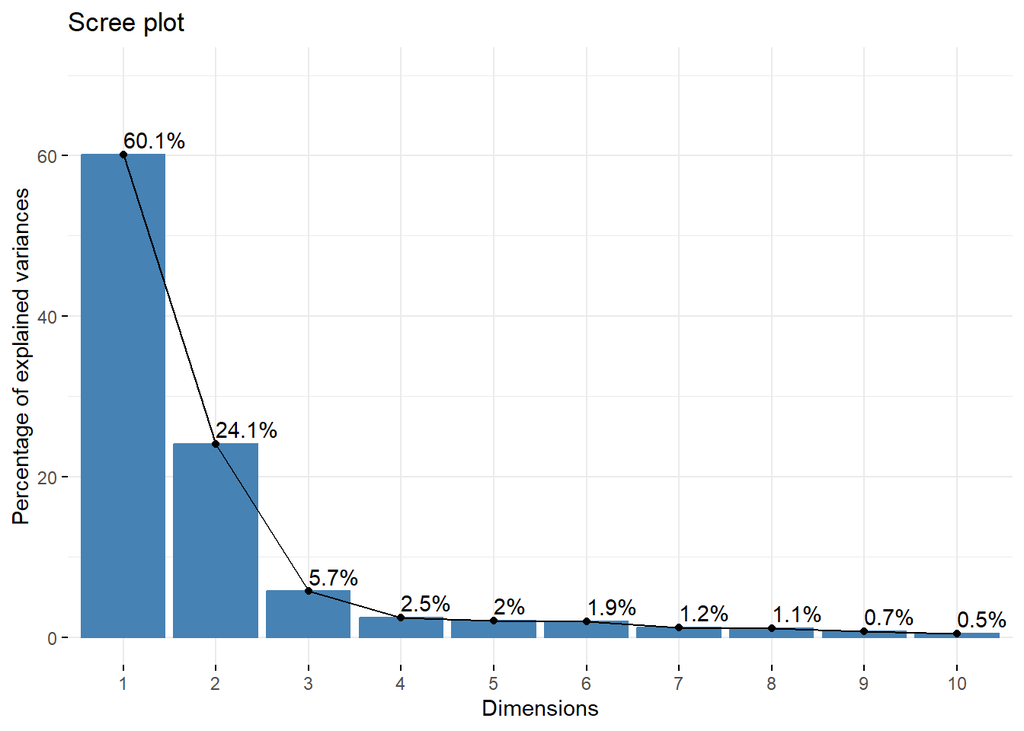

```r
fviz_eig(pc,
         addlabels = TRUE,
         ylim = c(0, 70))
```

#### biplot

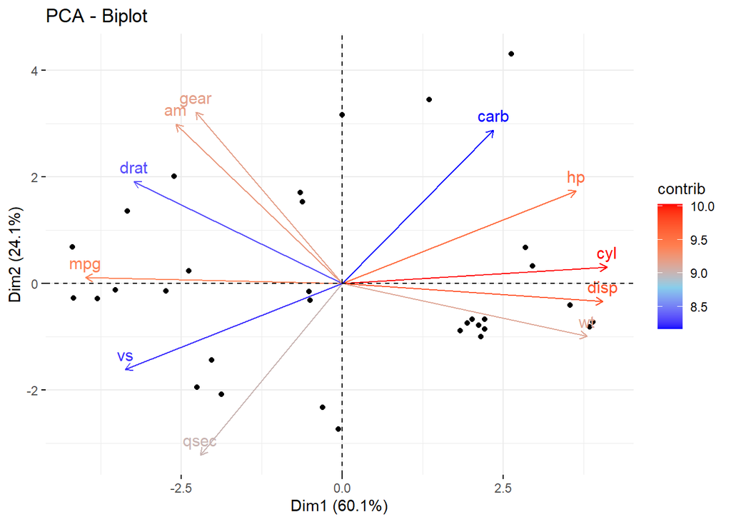

```r
fviz_pca_biplot(pc,
                label = "var",
                col.ind = "black",
                col.var = "contrib",
                gradient.cols = c("blue","skyblue","coral","red"))
```

#### d.) Discuss the insights gained from the PCA.

From the scree plot, the first 3 principal components are chosen as they explain most of the variation in the data. After which the variance explained stops being significantly different. the total variance explained by the three variables is `89.9%` which is an acceptable range.

Taking just the three PC to explain variation in cars we find that:

```r
eig.values[, 1:3]
```

```
##             PC1         PC2         PC3
## mpg   0.3625305 -0.01612440  0.22574419
## cyl  -0.3739160 -0.04374371  0.17531118
## disp -0.3681852  0.04932413  0.06148414
## hp   -0.3300569 -0.24878402 -0.14001476
## drat  0.2941514 -0.27469408 -0.16118879
## wt   -0.3461033  0.14303825 -0.34181851
## qsec  0.2004563  0.46337482 -0.40316904
## vs    0.3065113  0.23164699 -0.42881517
## am    0.2349429 -0.42941765  0.20576657
## gear  0.2069162 -0.46234863 -0.28977993
## carb -0.2140177 -0.41357106 -0.52854459
```

from this result

> **PC1**

> explains that cars vary mostly based on
> - Number of cylinders
> - mpg
> - engine displacement

> **PC2**

> explains that cars vary mostly based on
> - quarter mile time
> - Number of gears
> - Number of carburetors

> **PC3**

> explains that cars vary mostly based on
> - Number of carburetors
> - Whether the car has a v-shaped engine or a straight engine
> - And the quarter mile time

**From the Biplot**

basing the findings on the key components of `pc1` , `pc2` and `pc3` . We find that

- As the **Number of Cylinders** in a car `increase` the **Miles per gallon** of the car reduce significantly. More cylinders indicate less miles can be covered with a US gallon of fuel.
- As the **Number of Cylinders** in a car `increase` the **engine displacement** of the car `increase` with a $\approx 1:1$ ratio. More cylinders indicate that the engine has a high capacity to burn fuel.
- In order to `reduce` the **quarter mile time** a driver may need to increase the number of gears in a $\approx 1:1$ ratio. An extra gear may shorten your quarter mile time significantly compared to an individual with one less gear
- High number of **carburetors** `negatively` impacts the **quarter mile time**
- cars with a **V-shaped engine are faster** over the quarter mile than cars with straight engines

High consumption cars tend to have many cylinders and a larger displacement

### 3. Discriminant Analysis

#### a.) Choose a categorical variable as the response variable.

**VS** has been chosen as a response variable.

It represents

- 0 v-shaped engines
- 1 straight engines

The **am** and **vs** columns are excluded as they only offer a binary response which is hard to use in trying to show the overlap in **vs**

#### Showing the overlap

```r
library(ggplot2)
scatter  = function(column){
  plot = ggplot(mtcars, aes_string(column, "disp")) +
    geom_point(aes(fill = vs), shape = 23, alpha = 0.75)+
    theme_minimal() +
    labs (title = paste("Distribution based on: ", column),
          y = column,
          x = "disp")
  print(plot)
}
```

```r
key_col = colnames(mtcars) [- c(9, 8)]
for (col in key_col){
  scatter(col)
}
```

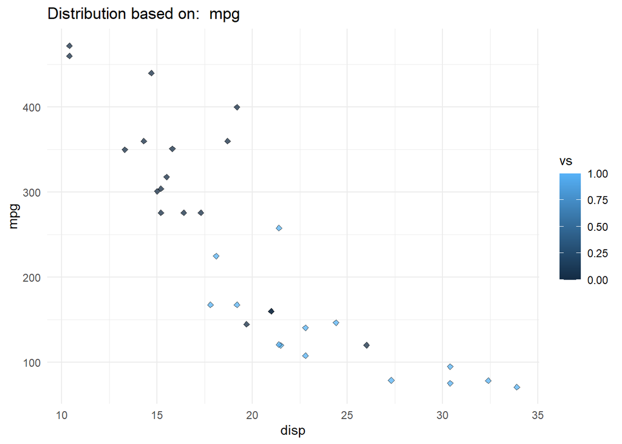

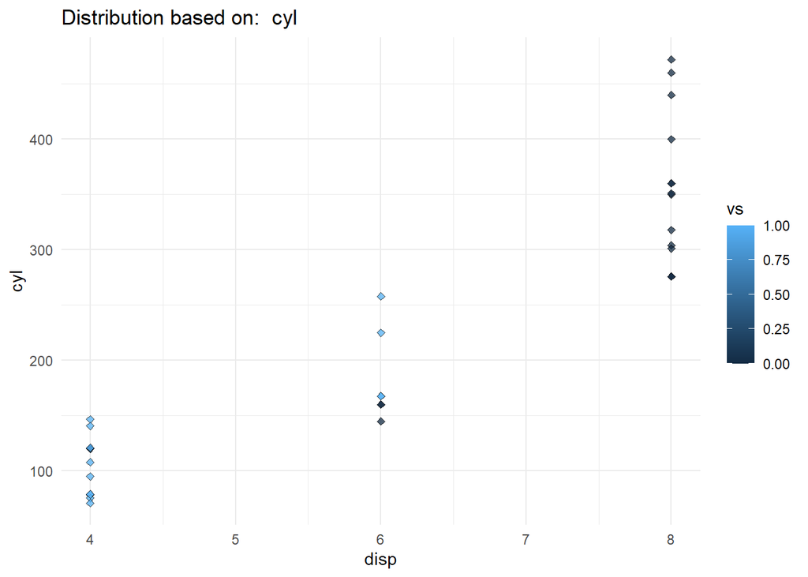

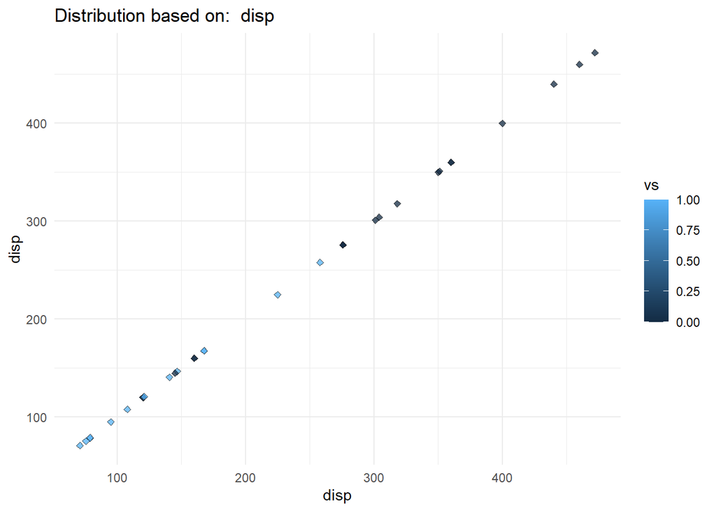

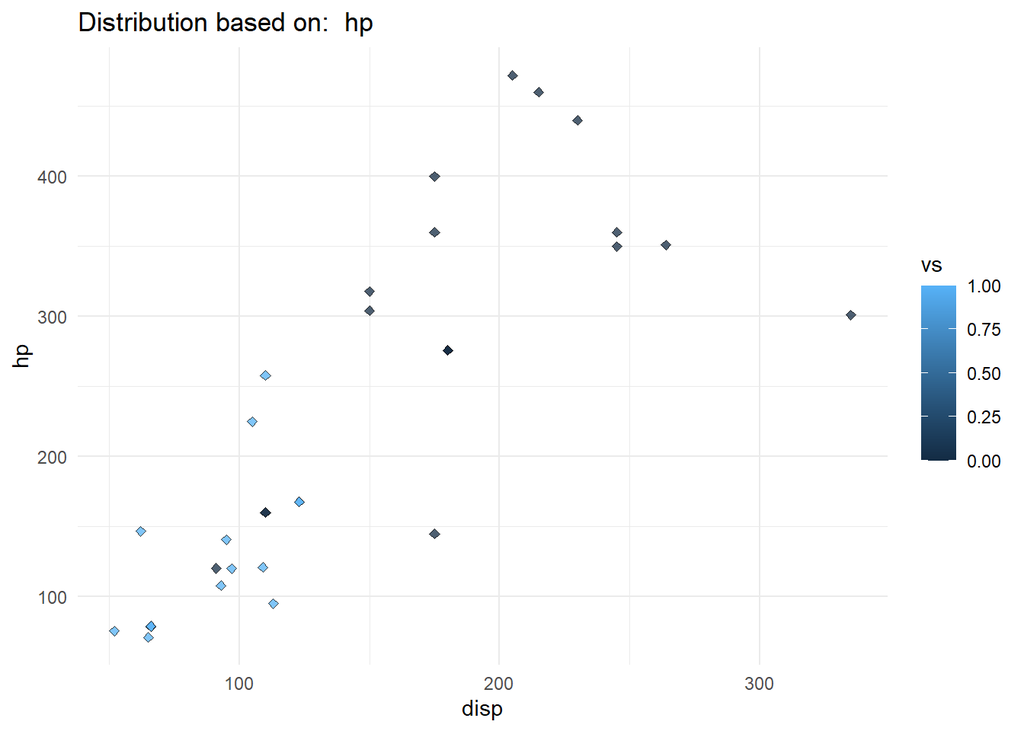

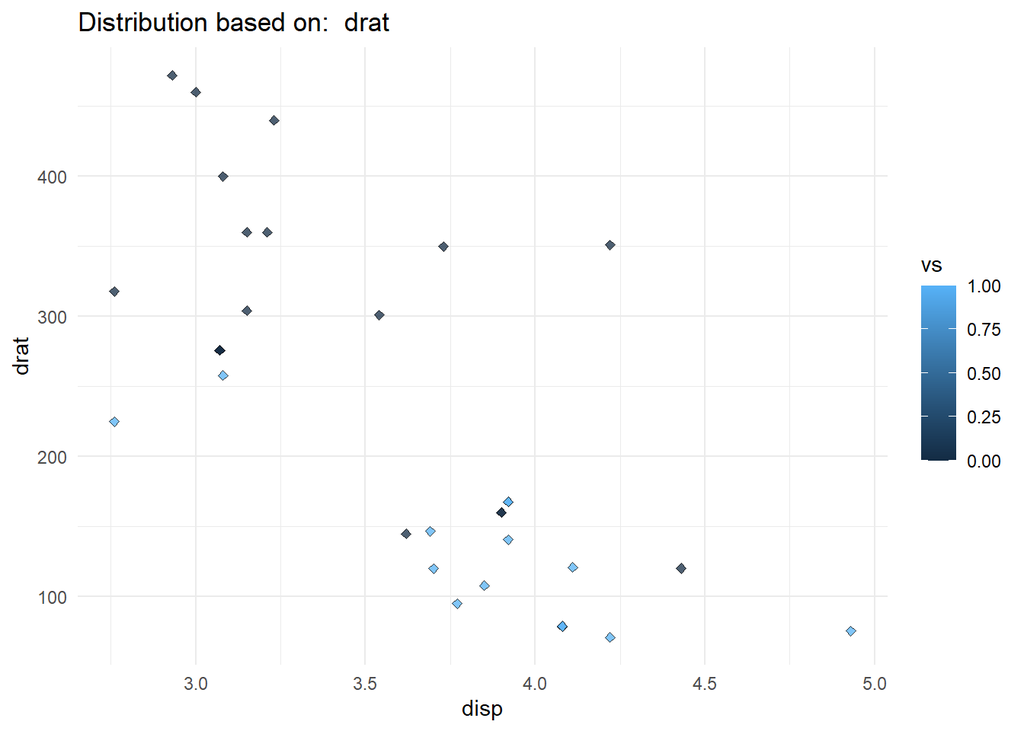

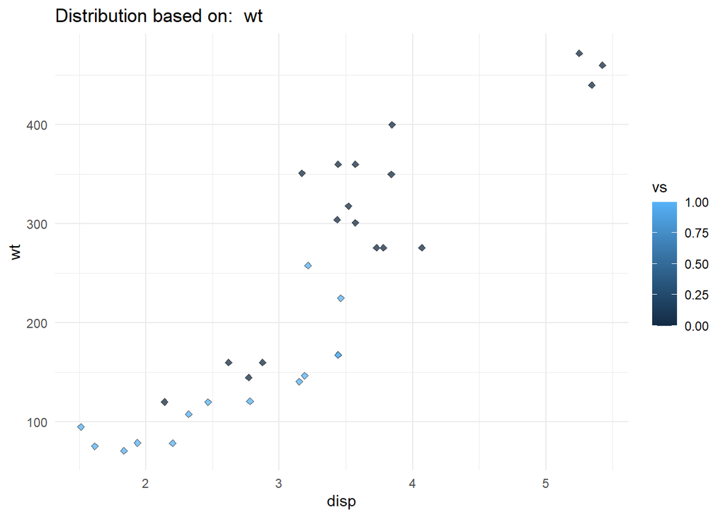

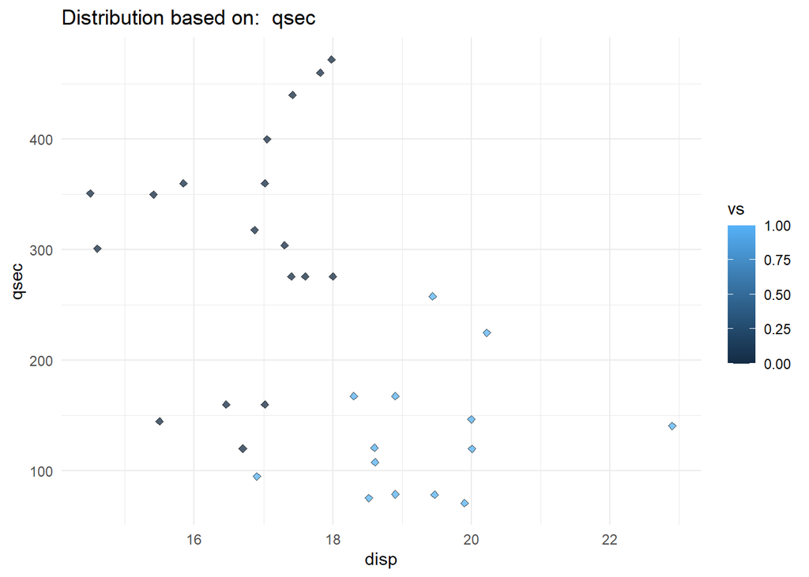

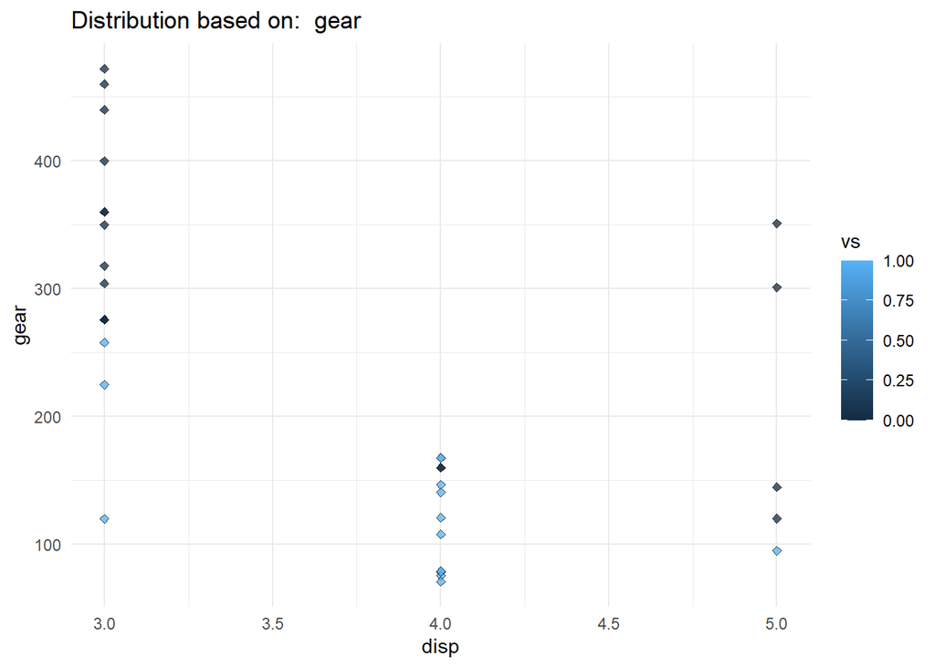

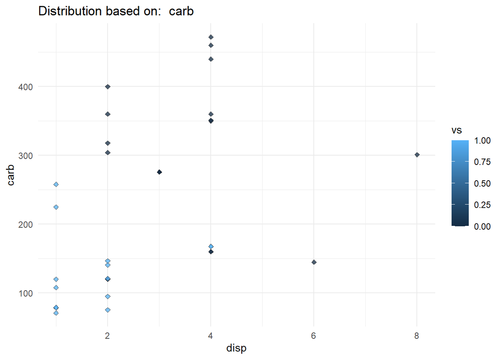

#### b.) Split the data set into training and testing sets.

```r
q3_data = mtcars[,-9]

# training and test data
set.seed(222)
ind_samp_seed = sample(2, nrow(q3_data),
 replace = TRUE,
prob = c(0.7, 0.3)) # separate the sample with replacement with the training set being 70% and 30% test data
train = q3_data[ind_samp_seed == 1,]
test = q3_data[ind_samp_seed == 2,]
nrow(train)
```

```
## [1] 23
```

#### Test for common covariance matric

```r
vengine = train[train$vs == 0,]
sengine = train[train$vs == 1,]

bartlett.test(vengine, sengine)
```

```
##
##  Bartlett test of homogeneity of variances
##
## data:  vengine
## Bartlett's K-squared = Inf, df = 9, p-value < 2.2e-16
```

> The bartlett’s test has a $H_o$ *that the two groups have no significant difference in their variance covariance* given a threshold of `0.05` above which we fail to reject $h_o$.

> This means that we need to perform a **Quadratic Discriminant Analysis**

#### Performing QDA

```r
vs_da = qda(vs~., data = q3_data)
pred = predict(vs_da, test, type = 'response')
```

#### d.) Evaluate the model’s performance on the testing set using appropriate metrics.

#### Using a contingency table to display output of prediction

```r
cont_tab = table(test$vs, pred$class)
nm = c("v-shaped", "straight")
colnames(cont_tab) = nm
rownames(cont_tab) = nm
cont_tab
```

```
##
##            v-shaped straight
##   v-shaped        6        0
##   straight        0        3
```

```r
accuracy = mean(pred$class == test$vs)
cat("Accuracy: ", accuracy*100, "%\n")
```

```
## Accuracy:  100 %
```

#### d.) Discuss the classification accuracy and the practical implications of the discriminant analysis.

**Classification Accuracy**

The model accurately groups the cars to either v-shaped engine or straight shaped engines.

This is because from the contingency matrix there is no mislabeled value. There are `6 v-shapped engine` cars and `3 straight engine cars` and when the model does a prediction, it classifies all the test data correctly.

Because of this the model seems to be able to fit `Accuracy` by correctly labeling the data as v or straight engine, `high precision` the proportion of accurate predictions is 1

```r
n_samples = 1000 # number of samples to bootstrap
bootstrap_samp = vector("list", n_samples)
samp_size = 9 # sample size similar to the test set size

for (i in 1: n_samples){
  boot_ind = sample(1:nrow(train), replace = TRUE) # generate multiple indexes of size 9 each round the loop starts
  bootstrap_samp[[i]] = train[boot_ind,]
}
```

```r
acc = function(sample){
  pred = predict(vs_da, sample, type = 'response')
  accuracy = mean(pred$class == sample$vs)
  return(accuracy)
}
```

```r
recall = c()
for (i in 1:n_samples){
  recall[i] = acc(bootstrap_samp[[i]])
}
recall
```

```
##    [1] 1 1 1 1 1 1 1 1 1 1 1 1 1 1 1 1 1 1 1 1 1 1 1 1 1 1 1 1 1 1 1 1 1 1 1 1 1
##   [38] 1 1 1 1 1 1 1 1 1 1 1 1 1 1 1 1 1 1 1 1 1 1 1 1 1 1 1 1 1 1 1 1 1 1 1 1 1
##   [75] 1 1 1 1 1 1 1 1 1 1 1 1 1 1 1 1 1 1 1 1 1 1 1 1 1 1 1 1 1 1 1 1 1 1 1 1 1
##  [112] 1 1 1 1 1 1 1 1 1 1 1 1 1 1 1 1 1 1 1 1 1 1 1 1 1 1 1 1 1 1 1 1 1 1 1 1 1
##  [149] 1 1 1 1 1 1 1 1 1 1 1 1 1 1 1 1 1 1 1 1 1 1 1 1 1 1 1 1 1 1 1 1 1 1 1 1 1
##  [186] 1 1 1 1 1 1 1 1 1 1 1 1 1 1 1 1 1 1 1 1 1 1 1 1 1 1 1 1 1 1 1 1 1 1 1 1 1
##  [223] 1 1 1 1 1 1 1 1 1 1 1 1 1 1 1 1 1 1 1 1 1 1 1 1 1 1 1 1 1 1 1 1 1 1 1 1 1
##  [260] 1 1 1 1 1 1 1 1 1 1 1 1 1 1 1 1 1 1 1 1 1 1 1 1 1 1 1 1 1 1 1 1 1 1 1 1 1
##  [297] 1 1 1 1 1 1 1 1 1 1 1 1 1 1 1 1 1 1 1 1 1 1 1 1 1 1 1 1 1 1 1 1 1 1 1 1 1
##  [334] 1 1 1 1 1 1 1 1 1 1 1 1 1 1 1 1 1 1 1 1 1 1 1 1 1 1 1 1 1 1 1 1 1 1 1 1 1
##  [371] 1 1 1 1 1 1 1 1 1 1 1 1 1 1 1 1 1 1 1 1 1 1 1 1 1 1 1 1 1 1 1 1 1 1 1 1 1
##  [408] 1 1 1 1 1 1 1 1 1 1 1 1 1 1 1 1 1 1 1 1 1 1 1 1 1 1 1 1 1 1 1 1 1 1 1 1 1
##  [445] 1 1 1 1 1 1 1 1 1 1 1 1 1 1 1 1 1 1 1 1 1 1 1 1 1 1 1 1 1 1 1 1 1 1 1 1 1
##  [482] 1 1 1 1 1 1 1 1 1 1 1 1 1 1 1 1 1 1 1 1 1 1 1 1 1 1 1 1 1 1 1 1 1 1 1 1 1
##  [519] 1 1 1 1 1 1 1 1 1 1 1 1 1 1 1 1 1 1 1 1 1 1 1 1 1 1 1 1 1 1 1 1 1 1 1 1 1
##  [556] 1 1 1 1 1 1 1 1 1 1 1 1 1 1 1 1 1 1 1 1 1 1 1 1 1 1 1 1 1 1 1 1 1 1 1 1 1
##  [593] 1 1 1 1 1 1 1 1 1 1 1 1 1 1 1 1 1 1 1 1 1 1 1 1 1 1 1 1 1 1 1 1 1 1 1 1 1
##  [630] 1 1 1 1 1 1 1 1 1 1 1 1 1 1 1 1 1 1 1 1 1 1 1 1 1 1 1 1 1 1 1 1 1 1 1 1 1
##  [667] 1 1 1 1 1 1 1 1 1 1 1 1 1 1 1 1 1 1 1 1 1 1 1 1 1 1 1 1 1 1 1 1 1 1 1 1 1
##  [704] 1 1 1 1 1 1 1 1 1 1 1 1 1 1 1 1 1 1 1 1 1 1 1 1 1 1 1 1 1 1 1 1 1 1 1 1 1
##  [741] 1 1 1 1 1 1 1 1 1 1 1 1 1 1 1 1 1 1 1 1 1 1 1 1 1 1 1 1 1 1 1 1 1 1 1 1 1
##  [778] 1 1 1 1 1 1 1 1 1 1 1 1 1 1 1 1 1 1 1 1 1 1 1 1 1 1 1 1 1 1 1 1 1 1 1 1 1
##  [815] 1 1 1 1 1 1 1 1 1 1 1 1 1 1 1 1 1 1 1 1 1 1 1 1 1 1 1 1 1 1 1 1 1 1 1 1 1
##  [852] 1 1 1 1 1 1 1 1 1 1 1 1 1 1 1 1 1 1 1 1 1 1 1 1 1 1 1 1 1 1 1 1 1 1 1 1 1
##  [889] 1 1 1 1 1 1 1 1 1 1 1 1 1 1 1 1 1 1 1 1 1 1 1 1 1 1 1 1 1 1 1 1 1 1 1 1 1
##  [926] 1 1 1 1 1 1 1 1 1 1 1 1 1 1 1 1 1 1 1 1 1 1 1 1 1 1 1 1 1 1 1 1 1 1 1 1 1
##  [963] 1 1 1 1 1 1 1 1 1 1 1 1 1 1 1 1 1 1 1 1 1 1 1 1 1 1 1 1 1 1 1 1 1 1 1 1 1
## [1000] 1
```

```r
mean(recall)
```

```
## [1] 1
```

**Practical Implications**

The model developed by this QDA can:

the model may be limited because:

- the training data is limited so training on a large data set that allows for larger data samples to be developed during bootstrapping. This may lower the recall giving a more accurate measure of whether the model has high classification accuracy.